# R Notebook

# Community belonging

```r
library(tidyverse)
library(here)

community_belonging <- read_csv(here("clean_data/community_belonging.csv")) %>%
  mutate(community_belonging = factor(community_belonging,
                                      levels = c("Not at all strongly",
                                                 "Not very strongly",
                                                 "Don't know",
                                                 "Fairly strongly",
                                                 "Very strongly")))
```

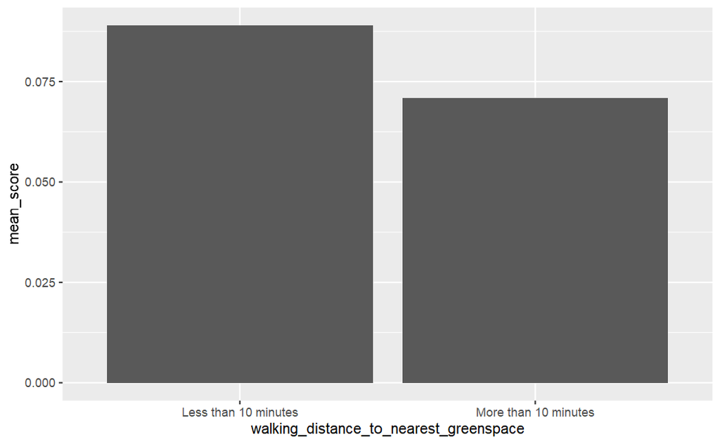

```r
community_belonging %>%
  filter(area == "Scotland", year == 2019, measurement == "Percent",
         walking_distance_to_nearest_greenspace != "All",
         walking_distance_to_nearest_greenspace != "Don't Know") %>%
  group_by(walking_distance_to_nearest_greenspace) %>%
  summarise(mean_score = mean(score)) %>%
  ggplot(aes(walking_distance_to_nearest_greenspace, mean_score)) +
  geom_col()
```

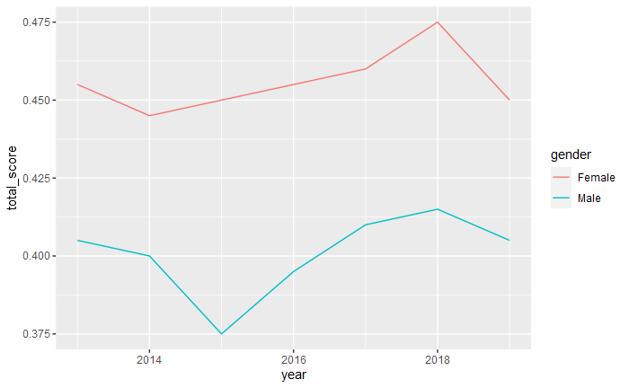

```r
community_belonging %>%
  filter(area == "Scotland", measurement == "Percent",
         gender != "All") %>%
  group_by(gender, year) %>%
  summarise(total_score = sum(score), total = n()) %>%
  ggplot(aes(year, total_score, colour = gender)) +
  geom_line()
```

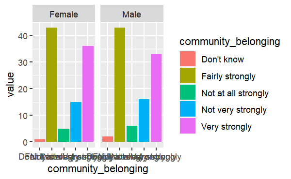

```r
community_belonging %>%
  filter(area == "Scotland", year == 2019, measurement == "Percent",
         gender != "All") %>%
  ggplot(aes(community_belonging, value, fill = community_belonging)) +
  geom_col() +
  facet_wrap(~gender)
```

# Neighbourhood rating

```r
neighbourhood_rating <- read_csv(here("clean_data/neighbourhood_rating.csv")) %>%
  mutate(neighbourhood_rating = factor(neighbourhood_rating,
                                       levels = c("Very poor",
                                                  "Fairly poor",
                                                  "No opinion",
                                                  "Fairly good",
                                                  "Very good"))
  )
neighbourhood_rating
```

| feature_code | year | measurement | value | neighbourhood_rating | gender | urban_rural_classification | simd_quintiles | type_of_tenure | household_type | ethnicity | walking_distance_to_nearest_greenspace | area | score |
| --- | --- | --- | --- | --- | --- | --- | --- | --- | --- | --- | --- | --- | --- |
| S12000033 | 2018 | 95% Lower Confidence Limit, Percent | 34.2 | Very good | All | All | All | All | All | All | More than 10 minutes | Aberdeen City | 0.3420 |
| S12000039 | 2016 | 95% Lower Confidence Limit, Percent | 35.1 | Very good | All | All | All | All | All | All | More than 10 minutes | West Dunbartonshire | 0.3510 |
| S12000039 | 2016 | 95% Upper Confidence Limit, Percent | 63.3 | Very good | All | All | All | All | All | All | More than 10 minutes | West Dunbartonshire | 0.6330 |
| S12000049 | 2013 | 95% Lower Confidence Limit, Percent | 1.5 | Very poor | All | All | All | All | All | All | More than 10 minutes | Glasgow City | -0.0150 |
| S12000036 | 2018 | 95% Upper Confidence Limit, Percent | 11.9 | Fairly poor | All | All | All | All | All | All | More than 10 minutes | City of Edinburgh | -0.0595 |
| S12000049 | 2014 | 95% Upper Confidence Limit, Percent | 5.7 | Very poor | All | All | All | All | All | All | More than 10 minutes | Glasgow City | -0.0570 |
| S12000034 | 2019 | Percent | 73.0 | Very good | All | All | All | All | All | All | More than 10 minutes | Aberdeenshire | 0.7300 |
| S12000023 | 2019 | Percent | 71.0 | Very good | All | All | All | All | All | All | More than 10 minutes | Orkney Islands | 0.7100 |
| S12000050 | 2019 | Percent | 42.0 | Very good | All | All | All | All | All | All | More than 10 minutes | North Lanarkshire | 0.4200 |
| S92000003 | 2013 | 95% Lower Confidence Limit, Percent | 38.1 | Fairly good | All | All | All | All | All | All | More than 10 minutes | Scotland | 0.1905 |

[output cut: 990 more lines]

[output not shown]

[output cut: 5 more lines]

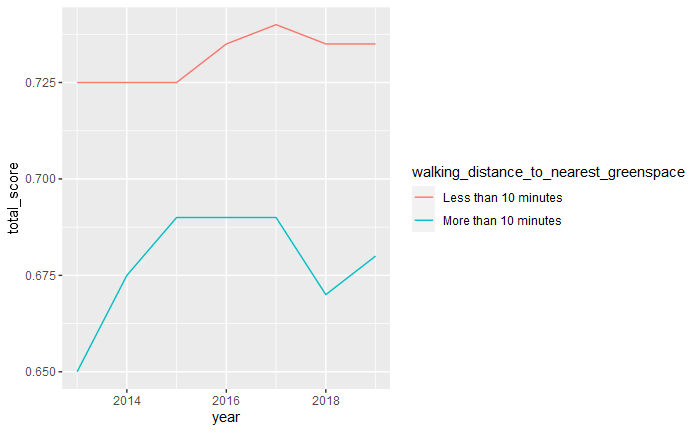

```r
neighbourhood_rating %>%
  filter(area == "Scotland", measurement == "Percent",
         !walking_distance_to_nearest_greenspace %in% c("All", "Don't Know")) %>%
  group_by(walking_distance_to_nearest_greenspace, year) %>%
  summarise(total_score = sum(score)) %>%
  ggplot(aes(year, total_score, colour = walking_distance_to_nearest_greenspace)) +
  geom_line()
```

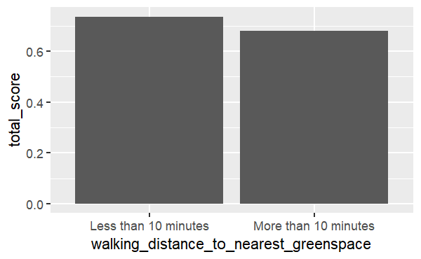

```r
neighbourhood_rating %>%
  filter(area == "Scotland", measurement == "Percent",
         !walking_distance_to_nearest_greenspace %in% c("All", "Don't Know"),
         year == 2019) %>%
  group_by(walking_distance_to_nearest_greenspace) %>%
  summarise(total_score = sum(score)) %>%
  ggplot(aes(walking_distance_to_nearest_greenspace, total_score)) +
  geom_col()
```

```r
neighbourhood_rating %>%
  group_by(walking_distance_to_nearest_greenspace) %>%
  summarise(count = n())
```

| walking_distance_to_nearest_greenspace | count |
| --- | --- |
| All | 34254 |
| Don't Know | 102 |
| Less than 10 minutes | 2970 |
| More than 10 minutes | 729 |

```r
(102/(3708+915))*100
```

```r
neighbourhood_rating %>%
  filter(area == "Na h-Eileanan Siar", year == 2016, measurement == "Percent",
         type_of_tenure != "All")
```

| feature_code | year | measurement | value | neighbourhood_rating | gender | urban_rural_classification | simd_quintiles | type_of_tenure | household_type | ethnicity | walking_distance_to_nearest_greenspace | area | score |
| --- | --- | --- | --- | --- | --- | --- | --- | --- | --- | --- | --- | --- | --- |
| S12000013 | 2016 | Percent | 1 | Fairly poor | All | All | All | Owned Outright | All | All | All | Na h-Eileanan Siar | -0.005 |
| S12000013 | 2016 | Percent | 89 | Very good | All | All | All | Owned Outright | All | All | All | Na h-Eileanan Siar | 0.890 |
| S12000013 | 2016 | Percent | 11 | Fairly good | All | All | All | Owned Outright | All | All | All | Na h-Eileanan Siar | 0.055 |

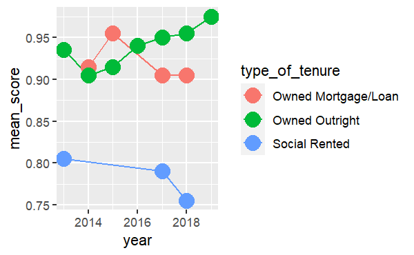

```r
neighbourhood_rating %>%
      filter(area == "Na h-Eileanan Siar", measurement == "Percent",
             type_of_tenure != "All") %>%
      summarise(mean_score = sum(score),
                .by = c(year, type_of_tenure)) %>%
      ggplot(aes(year, mean_score, colour = type_of_tenure)) +
      geom_line() +
      geom_point(size = 5)
```

# Join the data?

```r
community_belonging
neighbourhood_rating
```

```r
neighbourhood_rating_id <- neighbourhood_rating %>%
  mutate(rating = case_when(
    neighbourhood_rating == "Very good" ~ 5,
    neighbourhood_rating == "Fairly good" ~ 4,
    neighbourhood_rating == "No opinion" ~ 3,
    neighbourhood_rating == "Fairly poor" ~ 2,
    neighbourhood_rating == "Very poor" ~ 1
  ),
  measurement = case_when(
    str_detect(measurement, "Lower") ~ "Lower",
    str_detect(measurement, "Upper") ~ "Upper",
    .default = "Percent"
  )) %>%
  rowwise() %>%
  mutate(
    id = str_c(feature_code, year, measurement, gender,
               urban_rural_classification, simd_quintiles, type_of_tenure,
               household_type, ethnicity,
               walking_distance_to_nearest_greenspace, rating)
  ) %>%
  ungroup() %>%
  select(-neighbourhood_rating) %>%
  rename("neighbourhood_value" = value)

community_belonging_id <- community_belonging %>%
  mutate(rating = case_when(
    community_belonging == "Not at all strongly" ~ 1,
    community_belonging == "Not very strongly" ~ 2,
    community_belonging == "Don't know" ~ 3,
    community_belonging == "Fairly strongly" ~ 4,
    community_belonging == "Very strongly" ~ 5
  ),
  measurement = case_when(
    str_detect(measurement, "Lower") ~ "Lower",
    str_detect(measurement, "Upper") ~ "Upper",
    .default = "Percent"
  )) %>%
  rowwise() %>%
  mutate(
    id = str_c(feature_code, year, measurement, gender,
               urban_rural_classification, simd_quintiles, type_of_tenure,
               household_type, ethnicity,
               walking_distance_to_nearest_greenspace, rating)
  ) %>%
  ungroup() %>%
  select(-community_belonging) %>%
  rename("community_value" = value)
```

```r
community_belonging_id %>%
  summarise(across(.cols = everything(), .fns = ~sum(is.na(.x))))

neighbourhood_rating_id %>%
  summarise(across(.cols = everything(), .fns = ~sum(is.na(.x))))
```

```r
ratings_joined <- neighbourhood_rating_id %>%
  select(-c(feature_code, year, measurement, gender,
            urban_rural_classification, simd_quintiles, type_of_tenure,
            household_type, ethnicity, area,
            walking_distance_to_nearest_greenspace, rating)) %>%
  full_join(community_belonging_id, by = join_by(id)) %>%
  select(id, rating, measurement, community_value, score,
         neighbourhood_value, score, area, year,
         gender:walking_distance_to_nearest_greenspace) %>%
  arrange(area, year, rating)
```

The missing values seen in the raw analysis are now causing issues. It will be easier to do the analysis on the datasets separately.

```r
community_belonging_id %>%
  filter(feature_code == "S12000036", year == "2016", measurement == "Lower", rating == 3)
```

```r
ratings_joined %>%
  filter(area == "Scotland", measurement == "Percent",
         walking_distance_to_nearest_greenspace != "All") %>%
  group_by(walking_distance_to_nearest_greenspace, year) %>%
  summarise(mean_community = mean(score),
            mean_neighbourhood = mean(score)) %>%
  ggplot(aes(year, mean_community, colour = walking_distance_to_nearest_greenspace)) +
  geom_line()

ratings_joined %>%
  filter(area == "Scotland", measurement == "Percent",
         walking_distance_to_nearest_greenspace != "All") %>%
  group_by(walking_distance_to_nearest_greenspace, year) %>%
  summarise(mean_community = mean(score),
            mean_neighbourhood = mean(score)) %>%
  ggplot(aes(year, mean_neighbourhood, colour = walking_distance_to_nearest_greenspace)) +
  geom_line()
```

# Modelling

## Neighbourhood

```r
library(ggfortify)
library(GGally)
library(rpart)
library(rpart.plot)
```

## Aggregated modelling

```r
aggregated_ratings <- neighbourhood_rating %>%
  filter(measurement == "Percent", area == "Scotland") %>%
  group_by(year, gender, urban_rural_classification,
           simd_quintiles, type_of_tenure, household_type,
           ethnicity, walking_distance_to_nearest_greenspace) %>%
  summarise(score = sum(score))
```

```r
lm(score ~ ., aggregated_ratings) %>%
  summary()
```

```
Call:
lm(formula = score ~ ., data = aggregated_ratings)

Residuals:
      Min        1Q    Median        3Q       Max
-0.108571 -0.006518  0.001071  0.007500  0.046429

Coefficients:
                                                             Estimate Std. Error t value Pr(>|t|)
(Intercept)                                                -4.5700000  1.5661236  -2.918  0.00421 **
year                                                        0.0025000  0.0007768   3.218  0.00166 **
genderFemale                                                0.0085714  0.0098261   0.872  0.38480
genderMale                                                 -0.0021429  0.0098261  -0.218  0.82774
urban_rural_classificationRural                             0.1042857  0.0098261  10.613  < 2e-16 ***
urban_rural_classificationUrban                            -0.0221429  0.0098261  -2.253  0.02606 *
simd_quintiles80% least deprived                            0.2800000  0.0098261  28.495  < 2e-16 ***
simd_quintilesAll                                           0.2271429  0.0098261  23.116  < 2e-16 ***
type_of_tenureOther                                        -0.0207143  0.0098261  -2.108  0.03712 *
type_of_tenureOwned Mortgage/Loan                           0.0435714  0.0098261   4.434 2.07e-05 ***
type_of_tenureOwned Outright                                0.0885714  0.0098261   9.014 4.03e-15 ***
type_of_tenurePrivate Rented                               -0.0378571  0.0098261  -3.853  0.00019 ***
type_of_tenureSocial Rented                                -0.1721429  0.0098261 -17.519  < 2e-16 ***
household_typeAll                                           0.0250000  0.0098261   2.544  0.01223 *
household_typePensioners                                    0.1014286  0.0098261  10.322  < 2e-16 ***
household_typeWith Children                                -0.0007143  0.0098261  -0.073  0.94217
ethnicityOther                                             -0.0535714  0.0098261  -5.452 2.74e-07 ***
ethnicityWhite                                              0.0057143  0.0098261   0.582  0.56198
walking_distance_to_nearest_greenspaceDon't Know           -0.0792857  0.0098261  -8.069 6.40e-13 ***
walking_distance_to_nearest_greenspaceLess than 10 minutes  0.0092857  0.0098261   0.945  0.34657
walking_distance_to_nearest_greenspaceMore than 10 minutes -0.0442857  0.0098261  -4.507 1.55e-05 ***
---
Signif. codes:  0 ‘***’ 0.001 ‘**’ 0.01 ‘*’ 0.05 ‘.’ 0.1 ‘ ’ 1

Residual standard error: 0.01838 on 119 degrees of freedom
Multiple R-squared:  0.9546,    Adjusted R-squared:  0.947
F-statistic: 125.1 on 20 and 119 DF,  p-value: < 2.2e-16
```

```r
aggregated_ratings_gender <- aggregated_ratings %>%
  filter(gender != "All")

lm(score ~ gender, aggregated_ratings_gender) %>%
  summary()
```

```
Call:
lm(formula = score ~ gender, data = aggregated_ratings_gender)

Residuals:
      Min        1Q    Median        3Q       Max
-0.015000 -0.008750  0.002143  0.004821  0.015000

Coefficients:
             Estimate Std. Error t value Pr(>|t|)
(Intercept)  0.730714   0.003571 204.600   <2e-16 ***
genderMale  -0.010714   0.005051  -2.121   0.0554 .
---
Signif. codes:  0 ‘***’ 0.001 ‘**’ 0.01 ‘*’ 0.05 ‘.’ 0.1 ‘ ’ 1

Residual standard error: 0.009449 on 12 degrees of freedom
Multiple R-squared:  0.2727,    Adjusted R-squared:  0.2121
F-statistic:   4.5 on 1 and 12 DF,  p-value: 0.0554
```

```r
aggregated_ratings_rural <- aggregated_ratings %>%
  filter(urban_rural_classification != "All")
aggregated_ratings_rural
```

| year | gender | urban_rural_classification | simd_quintiles | type_of_tenure | household_type | ethnicity | walking_distance_to_nearest_greenspace | score |
| --- | --- | --- | --- | --- | --- | --- | --- | --- |
| 2013 | All | Rural | All | All | All | All | All | 0.820 |
| 2013 | All | Urban | All | All | All | All | All | 0.680 |
| 2014 | All | Rural | All | All | All | All | All | 0.810 |
| 2014 | All | Urban | All | All | All | All | All | 0.695 |
| 2015 | All | Rural | All | All | All | All | All | 0.825 |
| 2015 | All | Urban | All | All | All | All | All | 0.695 |
| 2016 | All | Rural | All | All | All | All | All | 0.825 |
| 2016 | All | Urban | All | All | All | All | All | 0.715 |
| 2017 | All | Rural | All | All | All | All | All | 0.840 |
| 2017 | All | Urban | All | All | All | All | All | 0.710 |

[output cut: 4 more lines]

```r
lm(score ~ urban_rural_classification, aggregated_ratings_rural) %>%
  summary()
```

```
Call:
lm(formula = score ~ urban_rural_classification, data = aggregated_ratings_rural)

Residuals:
      Min        1Q    Median        3Q       Max
-0.020000 -0.005000 -0.001429  0.010000  0.015000

Coefficients:
                                 Estimate Std. Error t value Pr(>|t|)
(Intercept)                      0.826429   0.004345  190.21   <2e-16 ***
urban_rural_classificationUrban -0.126429   0.006145  -20.58    1e-10 ***
---
Signif. codes:  0 ‘***’ 0.001 ‘**’ 0.01 ‘*’ 0.05 ‘.’ 0.1 ‘ ’ 1

Residual standard error: 0.0115 on 12 degrees of freedom
Multiple R-squared:  0.9724,    Adjusted R-squared:  0.9701
F-statistic: 423.4 on 1 and 12 DF,  p-value: 1.001e-10
```

```r
n_data <- nrow(neighbourhood_rating)
test_prop <- 0.2

test_index <- sample(1:n_data, n_data * test_prop)

neighbour_test <- slice(neighbourhood_rating, test_index)
neighbour_train <- slice(neighbourhood_rating, -test_index)
```

```r
neighbour_train %>%
  filter(measurement == "Percent") %>%
  select(score, year, gender, urban_rural_classification,
         simd_quintiles) %>%
  ggpairs()

neighbour_train %>%
  filter(measurement == "Percent") %>%
  select(score, walking_distance_to_nearest_greenspace, ethnicity,
         household_type, type_of_tenure) %>%
  ggpairs()
```

# Non-aggregated modelling

```r
mod1a <- lm(score ~ urban_rural_classification, neighbour_train)
mod1b <- lm(score ~ simd_quintiles, neighbour_train)

summary(mod1a)
```

```
Call:
lm(formula = score ~ urban_rural_classification, data = neighbour_train)

Residuals:
    Min      1Q  Median      3Q     Max
-0.4014 -0.1961 -0.1657  0.1139  0.8139

Coefficients:
                                 Estimate Std. Error t value Pr(>|t|)
(Intercept)                      0.186076   0.001613 115.358  < 2e-16 ***
urban_rural_classificationRural  0.058311   0.008682   6.716  1.9e-11 ***
urban_rural_classificationUrban -0.016216   0.005687  -2.851  0.00436 **
---
Signif. codes:  0 ‘***’ 0.001 ‘**’ 0.01 ‘*’ 0.05 ‘.’ 0.1 ‘ ’ 1

Residual standard error: 0.2656 on 30441 degrees of freedom
Multiple R-squared:  0.001817,  Adjusted R-squared:  0.001751
F-statistic:  27.7 on 2 and 30441 DF,  p-value: 9.524e-13
```

```r
summary(mod1b)
```

```
Call:
lm(formula = score ~ simd_quintiles, data = neighbour_train)

Residuals:
    Min      1Q  Median      3Q     Max
-0.3992 -0.1992 -0.1292  0.1308  0.8108

Coefficients:
                                 Estimate Std. Error t value Pr(>|t|)
(Intercept)                      0.108147   0.008509  12.710  < 2e-16 ***
simd_quintiles80% least deprived 0.082018   0.010141   8.088 6.31e-16 ***
simd_quintilesAll                0.081037   0.008660   9.358  < 2e-16 ***
---
Signif. codes:  0 ‘***’ 0.001 ‘**’ 0.01 ‘*’ 0.05 ‘.’ 0.1 ‘ ’ 1

Residual standard error: 0.2654 on 30441 degrees of freedom
Multiple R-squared:  0.002883,  Adjusted R-squared:  0.002817
F-statistic:    44 on 2 and 30441 DF,  p-value: < 2.2e-16
```

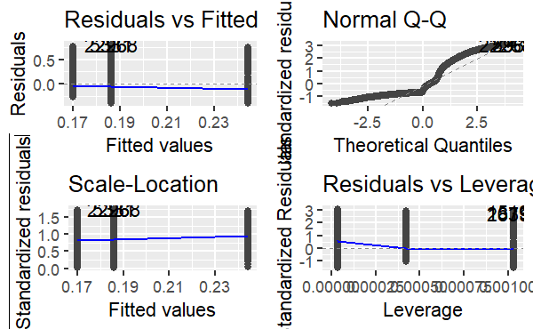

```r
autoplot(mod1a)
```

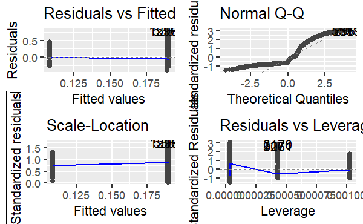

```r
autoplot(mod1b)
```

```r
mod2a <- lm(score ~ simd_quintiles + urban_rural_classification,
            neighbour_train)
mod2b <- lm(score ~ year + gender + urban_rural_classification +
              simd_quintiles + walking_distance_to_nearest_greenspace + ethnicity +
              household_type + type_of_tenure,
            neighbour_train)

summary(mod2a)
```

```
Call:
lm(formula = score ~ simd_quintiles + urban_rural_classification,
    data = neighbour_train)

Residuals:
    Min      1Q  Median      3Q     Max
-0.4014 -0.1969 -0.1349  0.1311  0.8111

Coefficients:
                                  Estimate Std. Error t value Pr(>|t|)
(Intercept)                       0.108147   0.008502  12.721  < 2e-16 ***
simd_quintiles80% least deprived  0.082018   0.010132   8.095 5.96e-16 ***
simd_quintilesAll                 0.080715   0.008673   9.306  < 2e-16 ***
urban_rural_classificationRural   0.055525   0.008691   6.389 1.69e-10 ***
urban_rural_classificationUrban  -0.019002   0.005711  -3.327 0.000878 ***
---
Signif. codes:  0 ‘***’ 0.001 ‘**’ 0.01 ‘*’ 0.05 ‘.’ 0.1 ‘ ’ 1

Residual standard error: 0.2652 on 30439 degrees of freedom
Multiple R-squared:  0.004668,  Adjusted R-squared:  0.004538
F-statistic: 35.69 on 4 and 30439 DF,  p-value: < 2.2e-16
```

```r
summary(mod2b)
```

```
Call:
lm(formula = score ~ year + gender + urban_rural_classification +
    simd_quintiles + walking_distance_to_nearest_greenspace +
    ethnicity + household_type + type_of_tenure, data = neighbour_train)

Residuals:
    Min      1Q  Median      3Q     Max
-0.4041 -0.1927 -0.1391  0.1471  0.8300

Coefficients:
                                                             Estimate Std. Error t value Pr(>|t|)
(Intercept)                                                -2.6850351  1.5232669  -1.763 0.077964 .
year                                                        0.0013915  0.0007555   1.842 0.065522 .
genderFemale                                                0.0178176  0.0077238   2.307 0.021070 *
genderMale                                                  0.0163294  0.0077576   2.105 0.035304 *
urban_rural_classificationRural                             0.0773077  0.0100248   7.712 1.28e-14 ***
urban_rural_classificationUrban                             0.0028957  0.0076154   0.380 0.703773
simd_quintiles80% least deprived                            0.0821145  0.0100832   8.144 3.98e-16 ***
simd_quintilesAll                                           0.0589307  0.0100100   5.887 3.97e-09 ***
walking_distance_to_nearest_greenspaceDon't Know           -0.0185200  0.0303558  -0.610 0.541802
walking_distance_to_nearest_greenspaceLess than 10 minutes  0.0096146  0.0076130   1.263 0.206629
walking_distance_to_nearest_greenspaceMore than 10 minutes  0.0015958  0.0122200   0.131 0.896099
ethnicityOther                                             -0.0192388  0.0198783  -0.968 0.333139
ethnicityWhite                                              0.0066938  0.0075858   0.882 0.377556
household_typeAll                                          -0.0121278  0.0077141  -1.572 0.115925
household_typePensioners                                    0.0568435  0.0081675   6.960 3.48e-12 ***
household_typeWith Children                                 0.0216407  0.0087276   2.480 0.013160 *
type_of_tenureOther                                        -0.0024369  0.0315583  -0.077 0.938449
type_of_tenureOwned Mortgage/Loan                           0.0639907  0.0084253   7.595 3.16e-14 ***
type_of_tenureOwned Outright                                0.0795450  0.0081305   9.784  < 2e-16 ***
type_of_tenurePrivate Rented                               -0.0160011  0.0144420  -1.108 0.267891
type_of_tenureSocial Rented                                -0.0307293  0.0084830  -3.622 0.000292 ***
---
Signif. codes:  0 ‘***’ 0.001 ‘**’ 0.01 ‘*’ 0.05 ‘.’ 0.1 ‘ ’ 1

Residual standard error: 0.2639 on 30423 degrees of freedom
Multiple R-squared:  0.01487,   Adjusted R-squared:  0.01422
F-statistic: 22.96 on 20 and 30423 DF,  p-value: < 2.2e-16
```

```r
autoplot(mod2b)
```

```r
mod3a <- lm(score ~ gender + urban_rural_classification +
              simd_quintiles + ethnicity + household_type + type_of_tenure,
            neighbour_train)
mod3b <- lm(score ~ gender + urban_rural_classification +
              simd_quintiles + household_type + type_of_tenure,
            neighbour_train)

summary(mod3a)
summary(mod3b)
```

```r
autoplot(mod3b)
```

### Conclusions

- Important factors are:
- gender
- urban/rural
- SIMD
- household type
- type of tenure

Most likely people to give higher neighbourhood ratings: - 80% least deprived - home owners (outright) - rural setting - home owners (mortgage) - pensioners - females

## Community

```r
n_data_2 <- nrow(community_belonging)

test_index <- sample(1:n_data_2, n_data_2 * test_prop)

community_test <- slice(community_belonging, test_index)
community_train <- slice(community_belonging, -test_index)
```

```r
community_train %>%
  filter(measurement == "Percent") %>%
  select(score, year, gender, urban_rural_classification, simd_quintiles) %>%
  ggpairs()

community_train %>%
  filter(measurement == "Percent") %>%
  select(score, walking_distance_to_nearest_greenspace, ethnicity,
         household_type, type_of_tenure) %>%
  ggpairs()
```

```r
mod1a <- lm(score ~ year + gender + urban_rural_classification +
              simd_quintiles + walking_distance_to_nearest_greenspace + ethnicity +
              household_type + type_of_tenure, community_train)
summary(mod1a)
```

```r
mod1b <- lm(score ~ gender + urban_rural_classification +
              simd_quintiles + walking_distance_to_nearest_greenspace + ethnicity +
              household_type + type_of_tenure, community_train)
summary(mod1b)
```

### Conclusions

- Important factors are:
- type of tenure
- SIMD
- ethnicity
- household type
- urban/rural
- walking distance to greenspace
- gender

*Least* likely people to feel greater community belonging: - private rented - non-white ethnicity - people who don’t where where the nearest greenspace is - other types of tenure

# Analysis

- What is the average community belonging?
- What is the average neighbourhood score?
- Which groups have a significantly higher score?
- Which groups have a significantly lower score?

```r
library(infer)
```

## Community/type of tenure

```r
average_community_belonging <- community_belonging %>%
  filter(measurement == "Percent") %>%
  summarise(avg_rating = mean(score)) %>%
  pull()

average_community_belonging
```

```r
community_belonging %>%
  filter(measurement == "Percent") %>%
  group_by(type_of_tenure) %>%
  summarise(avg_rating = mean(score),
            overall_avg = average_community_belonging)
```

### H0: `Owned Mortgage/Loan` and `Owned Outright` have the same mean (and can therefore be grouped)

```r
vars <- c("Owned Outright", "Owned Mortgage/Loan")

null_dist <- community_belonging %>%
  filter(type_of_tenure %in% vars) %>%
  specify(score ~ type_of_tenure) %>%
  hypothesise(null = "independence") %>%
  generate(reps = 500, type = "permute") %>%
  calculate(stat = "diff in means",
            order = vars)

obs_stat <- community_belonging %>%
  filter(type_of_tenure %in% vars) %>%
  specify(score ~ type_of_tenure) %>%
  calculate(stat = "diff in means",
            order = vars)
```

```r
null_dist %>%
  visualise() +
  shade_p_value(obs_stat = obs_stat, direction = "both")
```

```r
null_dist %>%
  get_p_value(obs_stat = obs_stat, direction = "both")
```

## H0: `Owned Outright` mean is greater than the average mean

```r
null_dist <- community_belonging %>%
  filter(type_of_tenure == "Owned Outright") %>%
  #select(score) %>%
  specify(response = score) %>%
  hypothesise(null = "point",
              mu = average_community_belonging) %>%
  generate(reps = 500, type = "bootstrap") %>%
  calculate(stat = "mean")

obs_stat <- community_belonging %>%
  filter(type_of_tenure == "Owned Outright") %>%
  specify(response = score) %>%
  calculate(stat = "mean")
```

```r
null_dist %>%
  visualise() +
  shade_p_value(obs_stat = obs_stat, direction = "right")
```

```r
null_dist %>%
  get_p_value(obs_stat = obs_stat, direction = "both")
```

```r
null_dist <- community_belonging %>%
  select(score, type_of_tenure) %>%
  mutate(owned_outright = (type_of_tenure == "Owned Outright")) %>%
  select(-type_of_tenure) %>%
  specify(score ~ owned_outright) %>%
  hypothesise(null = "independence") %>%
  generate(reps = 500, type = "permute") %>%
  calculate(stat = "diff in means", order = c(TRUE, FALSE))

obs_stat <- community_belonging %>%
  select(score, type_of_tenure) %>%
  mutate(owned_outright = (type_of_tenure == "Owned Outright")) %>%
  select(-type_of_tenure) %>%
  specify(score ~ owned_outright) %>%
  calculate(stat = "diff in means", order = c(TRUE, FALSE))
```

```r
null_dist %>%
  visualise() +
  shade_p_value(obs_stat = obs_stat, direction = "right")
```

```r
null_dist %>%
  get_p_value(obs_stat = obs_stat, direction = "both")
```

### Owned outright has a statistically higher community rating than the average

## `Owned Mortgage/Loan`

```r
null_dist <- community_belonging %>%
  select(score, type_of_tenure) %>%
  mutate(owned_mortgage = (type_of_tenure == "Owned Mortgage/Loan")) %>%
  select(-type_of_tenure) %>%
  specify(score ~ owned_mortgage) %>%
  hypothesise(null = "independence") %>%
  generate(reps = 500, type = "permute") %>%
  calculate(stat = "diff in means", order = c(TRUE, FALSE))

obs_stat <- community_belonging %>%
  select(score, type_of_tenure) %>%
  mutate(owned_mortgage = (type_of_tenure == "Owned Mortgage/Loan")) %>%
  select(-type_of_tenure) %>%
  specify(score ~ owned_mortgage) %>%
  calculate(stat = "diff in means", order = c(TRUE, FALSE))
```

```r
null_dist %>%
  visualise() +
  shade_p_value(obs_stat = obs_stat, direction = "right")
```

```r
null_dist %>%
  get_p_value(obs_stat = obs_stat, direction = "right")
```

## `Private Rented`

```r
null_dist <- community_belonging %>%
  filter(type_of_tenure != "All") %>%
  select(score, type_of_tenure) %>%
  mutate(rented = (type_of_tenure == "Private Rented")) %>%
  select(-type_of_tenure) %>%
  specify(score ~ rented) %>%
  hypothesise(null = "independence") %>%
  generate(reps = 500, type = "permute") %>%
  calculate(stat = "diff in means", order = c(TRUE, FALSE))

obs_stat <- community_belonging %>%
  filter(type_of_tenure != "All") %>%
  select(score, type_of_tenure) %>%
  mutate(rented = (type_of_tenure == "Private Rented")) %>%
  select(-type_of_tenure) %>%
  specify(score ~ rented) %>%
  calculate(stat = "diff in means", order = c(TRUE, FALSE))
```

```r
null_dist %>%
  visualise() +
  shade_p_value(obs_stat = obs_stat, direction = "left")
```

```r
null_dist %>%
  get_p_value(obs_stat = obs_stat, direction = "left")
```

### Private rented has a statistically lower community rating than the average

## `Social Rented`

```r
null_dist <- community_belonging %>%
  filter(type_of_tenure %in% c("All", "Social Rented")) %>%
  select(score, type_of_tenure) %>%
  mutate(rented = (type_of_tenure == "Social Rented")) %>%
  select(-type_of_tenure) %>%
  specify(score ~ rented) %>%
  hypothesise(null = "independence") %>%
  generate(reps = 500, type = "permute") %>%
  calculate(stat = "diff in means", order = c(TRUE, FALSE))

obs_stat <- community_belonging %>%
  filter(type_of_tenure %in% c("All", "Social Rented")) %>%
  select(score, type_of_tenure) %>%
  mutate(rented = (type_of_tenure == "Social Rented")) %>%
  select(-type_of_tenure) %>%
  specify(score ~ rented) %>%
  calculate(stat = "diff in means", order = c(TRUE, FALSE))
```

```r
null_dist %>%
  visualise() +
  shade_p_value(obs_stat = obs_stat, direction = "both")
```

```r
null_dist %>%
  get_p_value(obs_stat = obs_stat, direction = "both") %>%
  pull()
```

### Social rented has no impact

# Function for statistical testing

```r
test_diff_in_means <- function(data, column, category, n_reps = 500){
  null_dist <- data %>%
    filter({{column}} %in% c("All", category)) %>%
    mutate(test = ({{column}} == category)) %>%
    specify(score ~ test) %>%
    hypothesise(null = "independence") %>%
    generate(reps = n_reps, type = "permute") %>%
    calculate(stat = "diff in means", order = c(TRUE, FALSE))

  obs_stat <- data %>%
    filter({{column}} %in% c("All", category)) %>%
    mutate(test = ({{column}} == category)) %>%
    specify(score ~ test) %>%
    calculate(stat = "diff in means", order = c(TRUE, FALSE))

  p <- null_dist %>%
    get_p_value(obs_stat = obs_stat, direction = "both") %>%
    pull()

  cat(category, ": p = ", p, sep = "")
}
```

```r
visualise_diff_in_means <- function(data, column, category, n_reps = 500){
  null_dist <- data %>%
    filter({{column}} %in% c("All", category)) %>%
    mutate(test = ({{column}} == category)) %>%
    specify(score ~ test) %>%
    hypothesise(null = "independence") %>%
    generate(reps = n_reps, type = "permute") %>%
    calculate(stat = "diff in means", order = c(TRUE, FALSE))

  obs_stat <- data %>%
    filter({{column}} %in% c("All", category)) %>%
    mutate(test = ({{column}} == category)) %>%
    specify(score ~ test) %>%
    calculate(stat = "diff in means", order = c(TRUE, FALSE))

  null_dist %>%
    visualise() +
    shade_p_value(obs_stat = obs_stat, direction = "both")
}
```

```r
test_diff_in_means(community_belonging, type_of_tenure, "Owned Outright")
visualise_diff_in_means(community_belonging, type_of_tenure, "Owned Outright")
```

# Visualisation of 2019 data for introduction

```r
create_2019_community_graph <- function(category){
  community_belonging %>%
    filter(area == "Scotland", measurement == "Percent",
           {{category}} != "All",year == "2019") %>%
    select({{category}}, community_belonging, value) %>%
    ggplot(aes(community_belonging, value
               , fill = {{category}})) +
    geom_col(position = "dodge") +
    geom_text(aes(label = paste(value, "%")),
              vjust = -1, position = position_dodge(0.9)) +
    scale_y_continuous(limits = c(0, 50)) +
    theme(axis.text.x = element_text(angle = 45, hjust = 1),
          panel.grid.major = element_blank(),
          panel.grid.minor = element_blank(),
          panel.background = element_blank(),
          text = element_text(size = 16)) +
    labs(
      title = "Community Belonging in 2019",
      x = "Community Belonging",
      y = "Percentage of survey responses",
      fill = "Classification"
    )
}
```

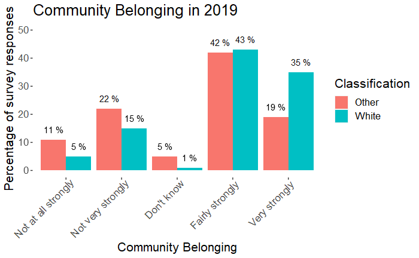

```r
categories <- c("ethnicity", "type_of_tenure", "simd_quintiles", "household_type",
                "urban_rural_classification", "gender", "walking_distance_to_nearest_greenspace")

create_2019_community_graph(ethnicity)
```

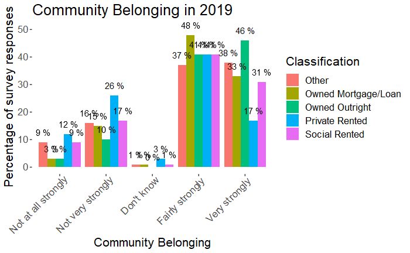

```r
create_2019_community_graph(type_of_tenure)
```

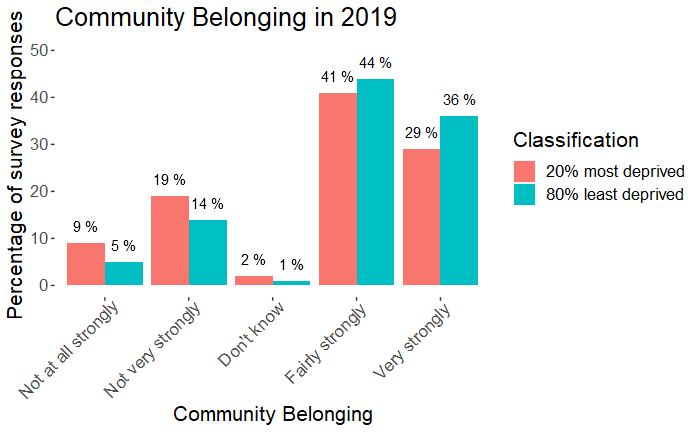

```r
create_2019_community_graph(simd_quintiles)
```

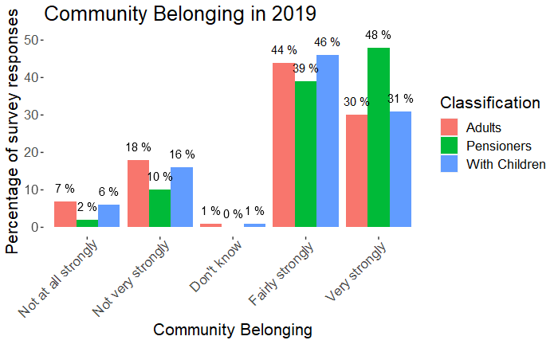

```r
create_2019_community_graph(household_type)
```

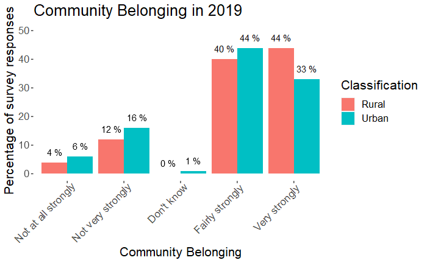

```r
create_2019_community_graph(urban_rural_classification)
```

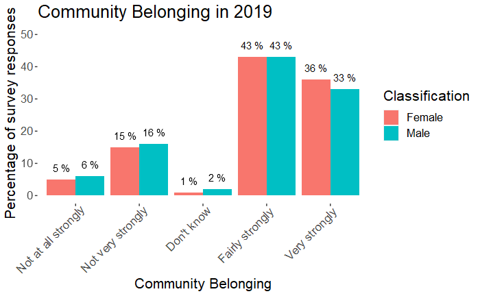

```r
create_2019_community_graph(gender)
```

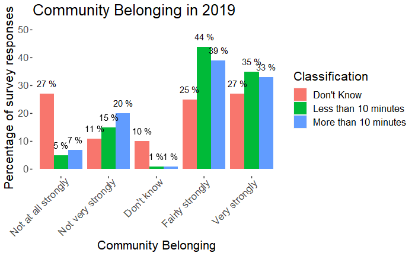

```r
create_2019_community_graph(walking_distance_to_nearest_greenspace)
```

```r
#ggsave("graphs_and_images/community_and_greenspace.png")
```

```r
create_2019_neighbourhood_graph <- function(category){
  neighbourhood_rating %>%
    filter(area == "Scotland", measurement == "Percent", {{category}} != "All",
           year == "2019") %>%
    select({{category}}, neighbourhood_rating, value) %>%
    ggplot(aes(neighbourhood_rating, value, fill = {{category}})) +
    geom_col(position = "dodge") +
    geom_text(aes(label = paste(value, "%")), vjust = -1, position = position_dodge(0.9)) +
    scale_y_continuous(limits = c(0, 100)) +
    theme(axis.text.x = element_text(angle = 45, hjust = 1),
          panel.grid.major = element_blank(),
          panel.grid.minor = element_blank(),
          panel.background = element_blank(),
          text = element_text(size = 16)) +
    labs(
      title = "Neighbourhood Rating in 2019",
      x = "Neighbourhood Rating",
      y = "Percentage of survey responses",
      fill = str_wrap(str_to_title(str_replace_all(deparse(substitute(category)),
                                                   "_", " ")), 20)
    )
}
```